# fazorsa_OriginalHomeworkCode_04

Frank Azorsa

11/5/2019

Peer commentary from nicfall: Awesome job, you’ve got some complicated code here. I would just maybe add a few comments here & there with a # so that someone new to your code would be able to follow your answers to Chris’s questions & what your code is doing a bit easier.

# Challenges

1. I am still adjusting details to my code for both questions.
2. Also, I am still working on the extra credit functions.

### [1] Using the “KamilarAndCooperData.csv” dataset, run a linear regression looking at log(HomeRange_km2) in relation to log(Body_mass_female_mean) and report your β coeffiecients (slope and intercept).

```r
library(curl)
library(car)
```

```r
library(ggplot2)
f <- curl("https://raw.githubusercontent.com/fuzzyatelin/fuzzyatelin.github.io/master/AN597_Fall19/KamilarAndCooperData.csv")
d <- read.csv(f, header = TRUE, sep = ",", stringsAsFactors = FALSE)
head(d)
```

```
##               Scientific_Name          Family          Genus      Species
## 1 Allenopithecus_nigroviridis Cercopithecidae Allenopithecus nigroviridis
## 2         Allocebus_trichotis Cercopithecidae      Allocebus    trichotis
## 3           Alouatta_belzebul        Atelidae       Alouatta     belzebul
## 4             Alouatta_caraya        Atelidae       Alouatta       caraya
## 5            Alouatta_guariba        Atelidae       Alouatta      guariba
## 6           Alouatta_palliata        Atelidae       Alouatta     palliata
##   Brain_Size_Species_Mean Brain_Size_Female_Mean   Brain_size_Ref
## 1                   58.02                  53.70 Isler et al 2008
## 2                      NA                     NA
## 3                   52.84                  51.19 Isler et al 2008
## 4                   52.63                  47.80 Isler et al 2008
## 5                   51.70                  49.08 Isler et al 2008
## 6                   49.88                  48.04 Isler et al 2008
##   Body_mass_male_mean Body_mass_female_mean Mass_Dimorphism
```

[output cut: 69 more lines]

```r
mod <- lm(data = d, log(HomeRange_km2) ~ log(Body_mass_female_mean))
summary(mod)
```

```
##
## Call:
## lm(formula = log(HomeRange_km2) ~ log(Body_mass_female_mean),
##     data = d)
##
## Residuals:
##     Min      1Q  Median      3Q     Max
## -3.3929 -0.9433 -0.0126  1.0944  3.6826
##
## Coefficients:
##                            Estimate Std. Error t value Pr(>|t|)
## (Intercept)                -9.44123    0.67293  -14.03   <2e-16 ***
## log(Body_mass_female_mean)  1.03643    0.08488   12.21   <2e-16 ***
## ---
## Signif. codes:  0 '***' 0.001 '**' 0.01 '*' 0.05 '.' 0.1 ' ' 1
##
## Residual standard error: 1.423 on 135 degrees of freedom
##   (76 observations deleted due to missingness)
## Multiple R-squared:  0.5248, Adjusted R-squared:  0.5213
## F-statistic: 149.1 on 1 and 135 DF,  p-value: < 2.2e-16
```

```r
goodline <- function(x,a,b, width = 1, colour = "black", type = 1){
  x1 <- min(x)
  x2 <- max(x)
  y1 <- a + b*x1
  y2 <- a + b*x2
  lines(c(x1,x2),c(y1,y2), lwd = width, col = colour, lty = type)
}
```

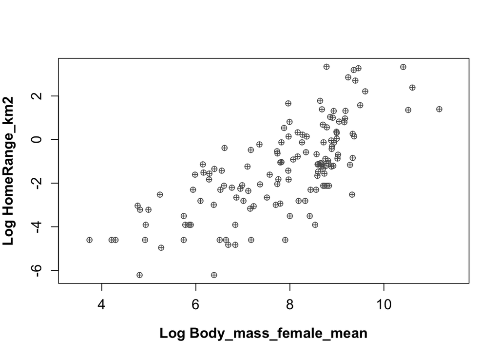

```r
#abline(a = -9.44, b = 1.04, lwd = 1.5, col ="grey35")#This does not work, I am not sure why.
plot(log(d$Body_mass_female_mean), log(d$HomeRange_km2), xlab = "Log Body_mass_female_mean", ylab = "Log HomeRange_km2", cex.axis = 1.2, font.lab = 2, cex.lab = 1.2, col = "grey35", pch =10)
goodline(log(x = d$Body_mass_female_mean), a = -9.44, b = 1.04, colour = "grey35", width = 1.5)
```

```r
attributes(mod)
```

```
## $names
##  [1] "coefficients"  "residuals"     "effects"       "rank"
##  [5] "fitted.values" "assign"        "qr"            "df.residual"
##  [9] "na.action"     "xlevels"       "call"          "terms"
## [13] "model"
##
## $class
## [1] "lm"
```

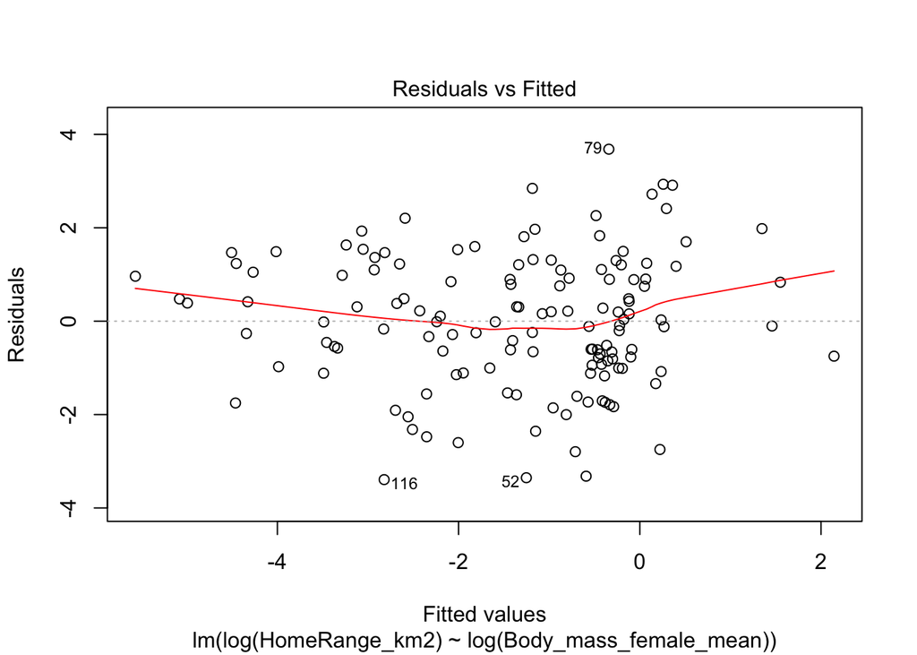

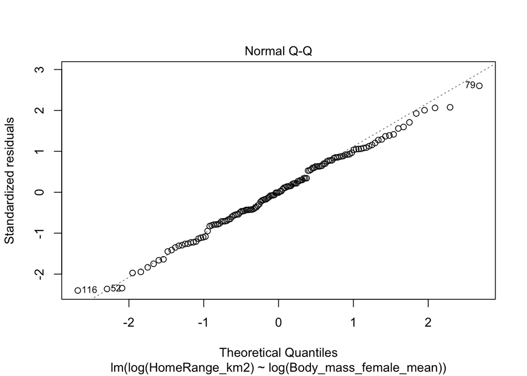

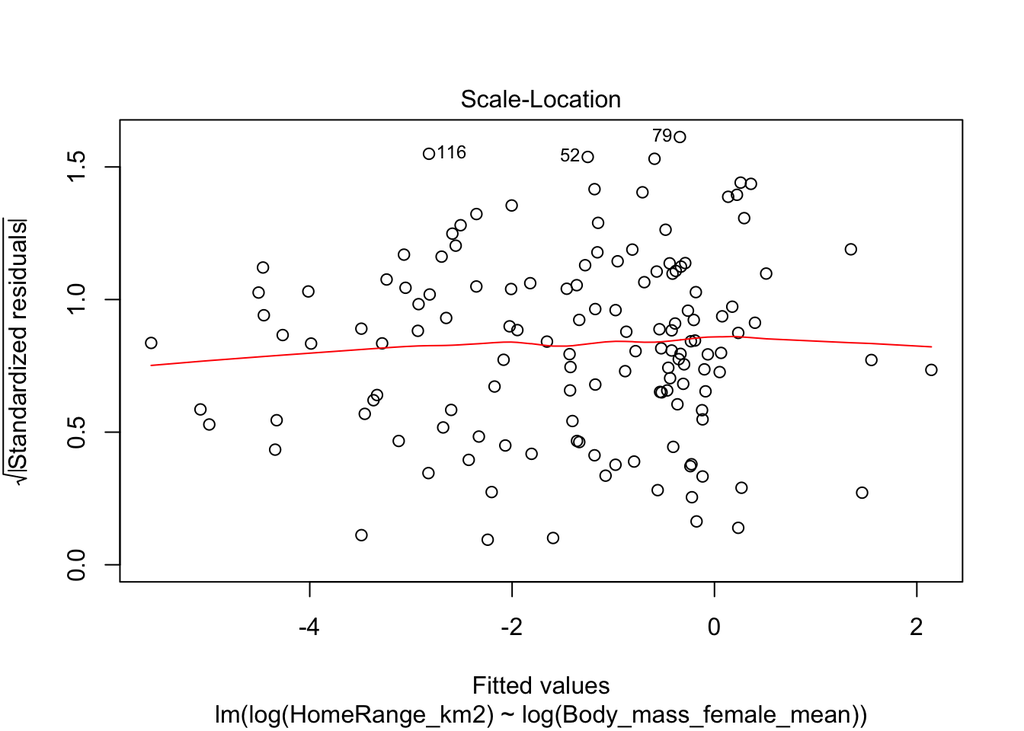

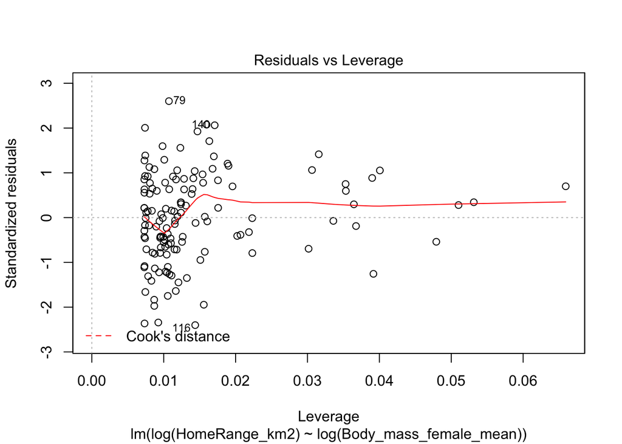

```r
plot(mod)
```

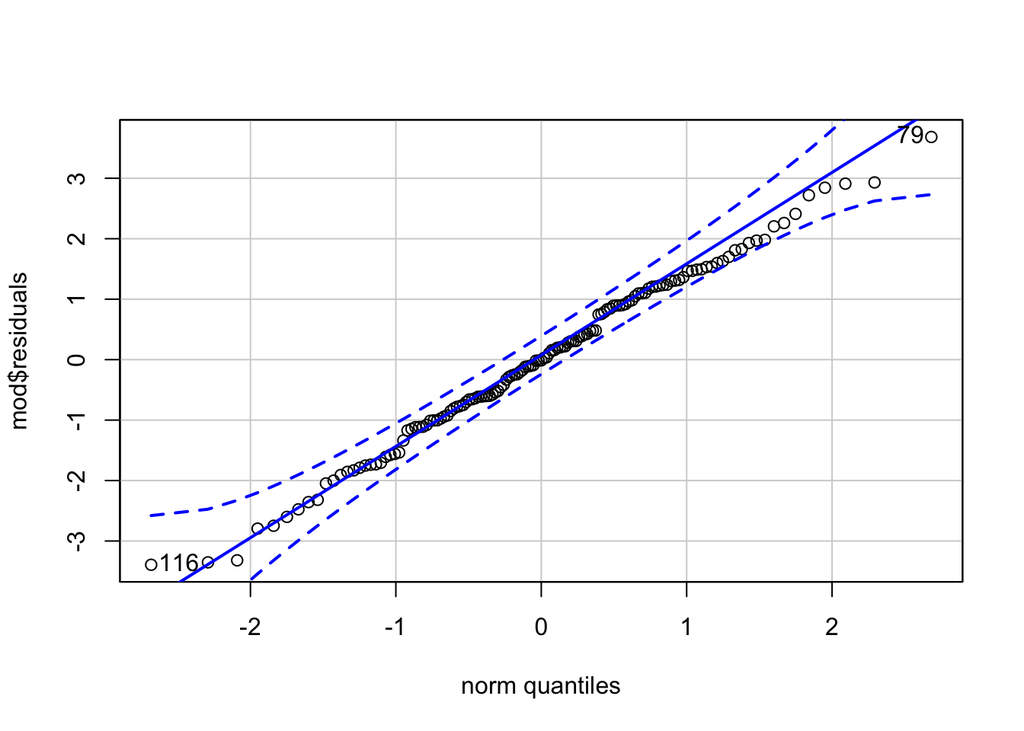

```
##  79 116
##  46  74
```

```r
qqPlot(mod$residuals)
```

```r
mod$coefficients
```

```
##                (Intercept) log(Body_mass_female_mean)
##                  -9.441231                   1.036432
```

```r
confint(mod)
```

```
##                                  2.5 %    97.5 %
## (Intercept)                -10.7720889 -8.110374
## log(Body_mass_female_mean)   0.8685707  1.204292
```

### [2] Then, use bootstrapping to sample from your data 1000 times with replacement, each time fitting the same model and calculating the same coefficients. This generates a sampling distribution for each β coefficient.

Estimate the standard error for each of your β coefficients as the standard deviation of the sampling distribution from your bootstrap and determine the 95% CI for each of your β coefficients based on the appropriate quantiles from your sampling distribution.

How does the former compare to the SE estimated from your entire dataset using the formula for standard error implemented in lm()?

How does the latter compare to the 95% CI estimated from your entire dataset?

```r
library(boot)
r_squared <- function(formula, data, indices) {
  val <- data[indices,]
  fit <- lm(formula, data=val)
  return(summary(fit)$r.square)
}
output <- boot(data=d, statistic = r_squared,
                R=1000, formula=log(HomeRange_km2)~log(Body_mass_female_mean))
output
```

```
##
## ORDINARY NONPARAMETRIC BOOTSTRAP
##
##
## Call:
## boot(data = d, statistic = r_squared, R = 1000, formula = log(HomeRange_km2) ~
##     log(Body_mass_female_mean))
##
##
## Bootstrap Statistics :
##      original      bias    std. error
## t1* 0.5248282 0.000580841  0.04840227
```

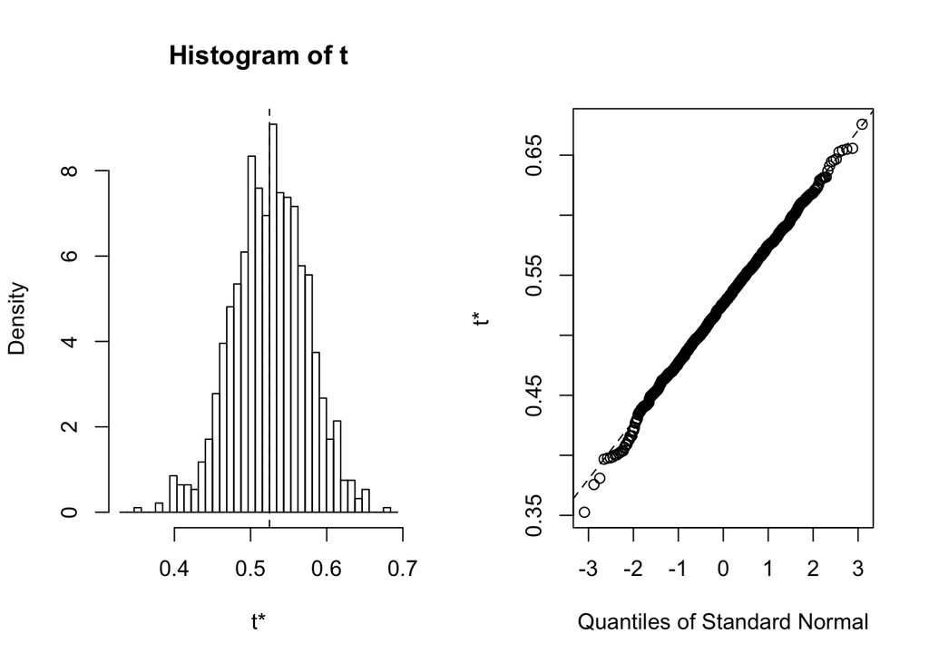

```r
plot(output)
```

```r
boot.ci(output, type = "bca")
```

```
## BOOTSTRAP CONFIDENCE INTERVAL CALCULATIONS
## Based on 1000 bootstrap replicates
##
## CALL :
## boot.ci(boot.out = output, type = "bca")
##
## Intervals :
## Level       BCa
## 95%   ( 0.4163,  0.6153 )
## Calculations and Intervals on Original Scale
```

```r
bs <- function(formula, data, indices) {
  d <- data[indices,]
  fit <- lm(formula, data=d)
  return(coef(fit))
}
results <- boot(data=d, statistic=bs,
   R=1000, formula=logHomeRange_km2~logFemaleBodyMass)
```

```
## Error in eval(predvars, data, env): object 'logHomeRange_km2' not found
```

```r
plot(results)
```

```
## Error in plot(results): object 'results' not found
```

```r
boot.ci(results)
```

```
## Error in boot.ci(results): object 'results' not found
```

```r
coefficients(results)
```

```
## Error in coefficients(results): object 'results' not found
```

```r
confint(results, level = 0.95)
```

```
## Error in confint(results, level = 0.95): object 'results' not found
```

# I am still working on this function.

Write a FUNCTION that takes as its arguments a dataframe, “d”, a linear model, “m” (as a character string, e.g., “logHR~logBM”), a user-defined confidence interval level, “conf.level” (with default = 0.95), and a number of bootstrap replicates, “n” (with default = 1000). Your function should return a dataframe that includes: beta coefficient names; beta coefficients, standard errors, and upper and lower CI limits for the linear model based on your entire dataset; and mean beta coefficient estimates, SEs, and CI limits for those coefficients based on your bootstrap.

# EXTRA EXTRA CREDIT

Graph each beta value from the linear model and its corresponding mean value, lower CI and upper CI from a bootstrap as a function of number of bootstraps from 10 to 200 by 10s. HINT: the beta value from the linear model will be the same for all bootstraps and the mean beta value may not differ that much!